# ggrob_OriginalHomeworkCode_03

Gianna Grob

10/2/2019

# Introduction

This is the code for the third homework assignment for AN597. It utilizes code from Modules 3-8. The data included in this homework includes the first and last name and gender of the entire population of 1000 people who have survived the zombie apocalypse and are now ekeing out an existence somewhere on the East Coast, along with several other variables (height, weight, age, number of years of education, number of zombies they have killed, and college major).

## Loading in the data and packages needed

First, I have to load in the data set provided by Professor Schmiit from his [GitHub repo](https://github.com/fuzzyatelin/fuzzyatelin.github.io/tree/master/AN597_Fall19/).

```r
library(curl)
f <- f <- curl("https://raw.githubusercontent.com/fuzzyatelin/fuzzyatelin.github.io/master/AN597_Fall19/zombies.csv")
d <- read.csv(f, header = TRUE, sep = ",", stringsAsFactors = FALSE) #Our vector for all of the zombie data is "d". This will be the vector we use for the homework when the whole data set is needed.
head(d) #See a summary of the data.
```

```
##   id first_name last_name gender   height   weight zombies_killed
## 1  1      Sarah    Little Female 62.88951 132.0872              2
## 2  2       Mark    Duncan   Male 67.80277 146.3753              5
## 3  3    Brandon     Perez   Male 72.12908 152.9370              1
## 4  4      Roger   Coleman   Male 66.78484 129.7418              5
## 5  5      Tammy    Powell Female 64.71832 132.4265              4
## 6  6    Anthony     Green   Male 71.24326 152.5246              1
##   years_of_education                           major      age
## 1                  1                medicine/nursing 17.64275
## 2                  3 criminal justice administration 22.58951
## 3                  1                       education 21.91276
## 4                  6                  energy studies 18.19058
## 5                  3                       logistics 21.10399
## 6                  4                  energy studies 21.48355
```

```r
library(ggplot2) #Load ggplot2 package.
```

## Question 1

Calculate the population mean and standard deviation for each quantitative random variable (height, weight, age, number of zombies killed, and years of education). NOTE: You will not want to use the built in var() and sd() commands as these are for samples.

### Height:

```r
h <- d$height #Create vector that has all of the heights of the people in the data set.

#Finding the mean:

pm1 <- function(h){sum(h)/length(h)}
pm1(h)
```

```
## [1] 67.6301
```

```r
#Finding the standard deviation:

var(h) * ((length(h)-1)/length(h)) #The difference from sample variance is by a factor of ((N-1)/N), so I do that here.
```

```
## [1] 18.55861
```

### Weight:

```r
w <- d$weight #Create vector that has all of the weights of the people in the data set.

#Finding the mean:

pm2 <- function(h){sum(w)/length(w)}
pm2(w)
```

```
## [1] 143.9075
```

```r
#Finding the standard deviation:

var(w) * ((length(w)-1)/length(w))
```

```
## [1] 338.2604
```

### Age:

```r
a <- d$age #Create vector that has all of the ages of the people in the data set.

#Finding the mean:

pm3 <- function(a){sum(a)/length(a)}
pm3(a)
```

```
## [1] 20.04696
```

```r
#Finding the standard deviation:

var(a) * ((length(a)-1)/length(a))
```

```
## [1] 8.782822
```

### Number of Zombies Killed:

```r
z <- d$zombies_killed #Create vector that has all of the numbers of zombies killed by the people in the data set.

#Finding the mean:

pm4 <- function(z){sum(z)/length(z)}
pm4(z)
```

```
## [1] 2.992
```

```r
#Finding the standard deviation:

var(z) * ((length(z)-1)/length(z))
```

```
## [1] 3.053936
```

### Years of Education:

```r
y <- d$years_of_education #Create vector that has all of the years of education of the people in the data set.

#Finding the mean:

pm5 <- function(y){sum(y)/length(y)}
pm5(y)
```

```
## [1] 2.996
```

```r
#Finding the standard deviation:

var(y) * ((length(y)-1)/length(y))
```

```
## [1] 2.807984
```

## Question 2

Use {ggplot} to make boxplots of each of these variables by gender.

```r
g <- d$gender #Create vector for gender for the boxplots.
```

I will be using the vectors that I created in the last question, as well as the “g” vector I just created in the boxplots. The “g” vector will always take the “x” value, while the other vectors will take the place of the “y” value in the scatterplots.

### Height

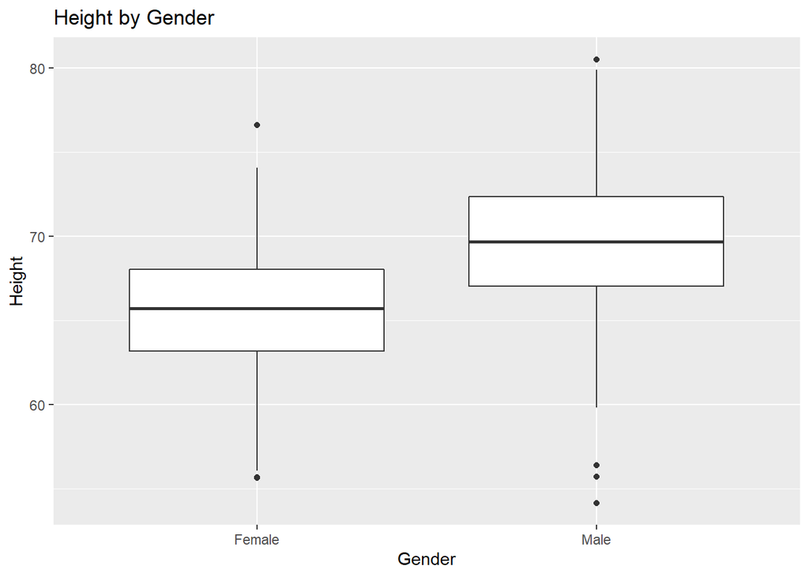

```r
ggplot(d, aes(x = g, y = h)) + labs(title="Height by Gender", x="Gender", y="Height") + geom_boxplot() #Create boxplot for height with gender.
```

### Weight

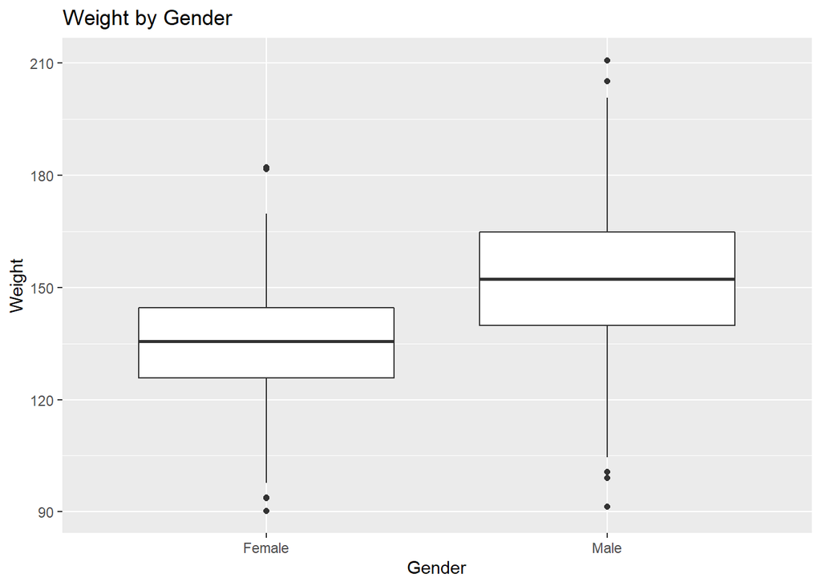

```r
ggplot(d, aes(x = g, y = w)) + labs(title="Weight by Gender", x="Gender", y="Weight") + geom_boxplot() #Create boxplot for weight with gender.
```

### Age

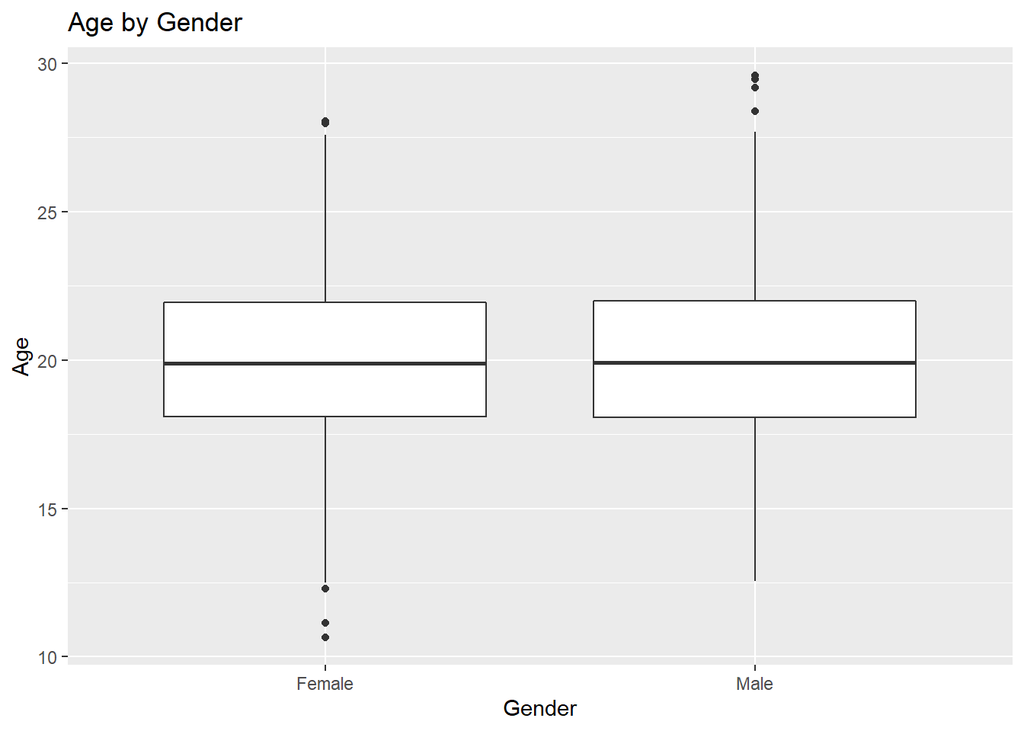

```r
ggplot(d, aes(x = g, y = a)) + labs(title="Age by Gender", x="Gender", y="Age") + geom_boxplot() #Create boxplot for age with gender.
```

### Number of Zombies Killed

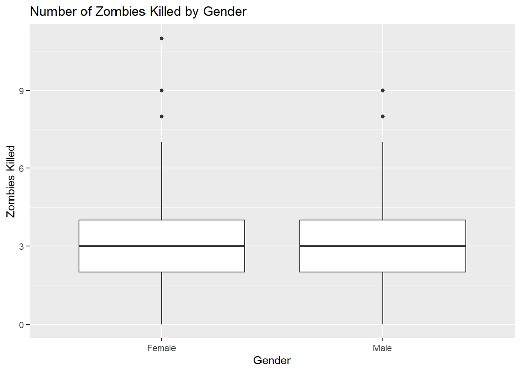

```r
ggplot(d, aes(x = g, y = z)) + labs(title="Number of Zombies Killed by Gender", x="Gender", y="Zombies Killed") + geom_boxplot() #Create boxplot for number of zombies killed with gender.
```

### Years of Education

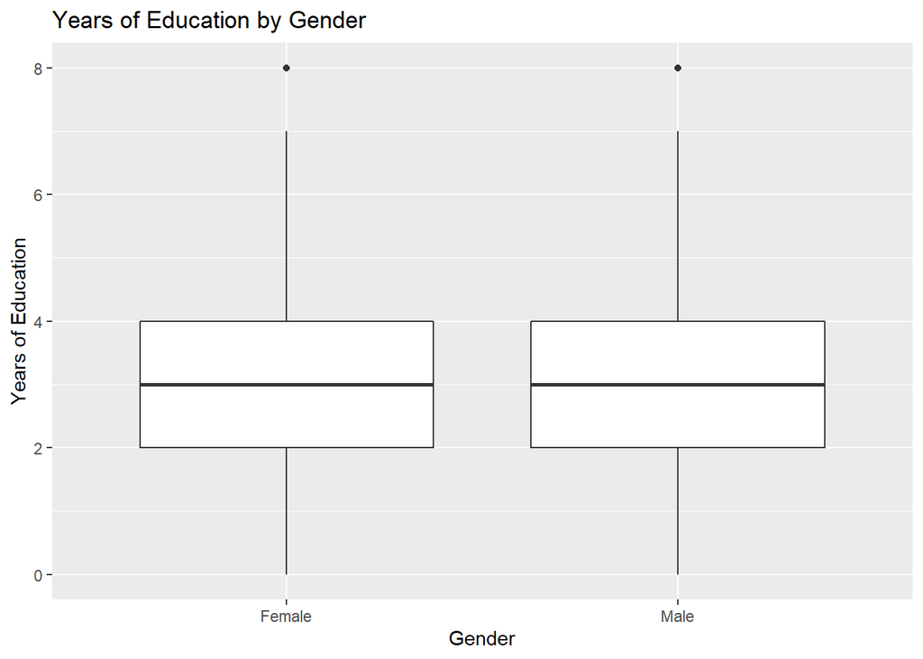

```r
ggplot(d, aes(x = g, y = y)) + labs(title="Years of Education by Gender", x="Gender", y="Years of Education") + geom_boxplot() #Create boxplot for years of education with gender.
```

## Question 3

Use {ggplot} to make scatterplots of height and weight in relation to age. Do these variables seem to be related? In what way?

I will continue to use the vectors I created in the above questions. These will take the place of the “x” and “y” values in the scatterplots.

### Height Scatterplot

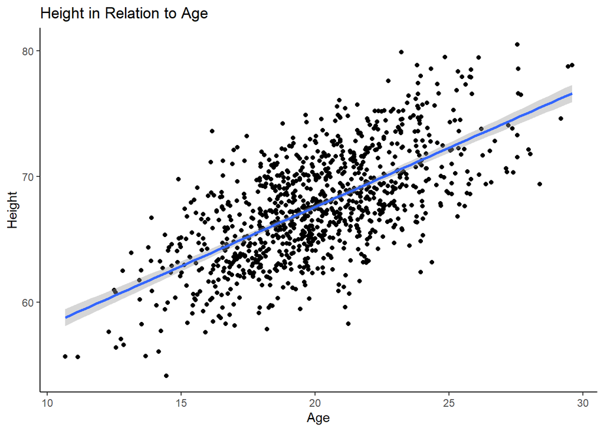

```r
ggplot(d, aes(x=a, y=h)) + geom_point() + geom_smooth(method=lm) + labs(title="Height in Relation to Age", x="Age", y="Height") + theme_classic() #Create scatterplot with height in relationship to age.
```

### Weight Scatterplot

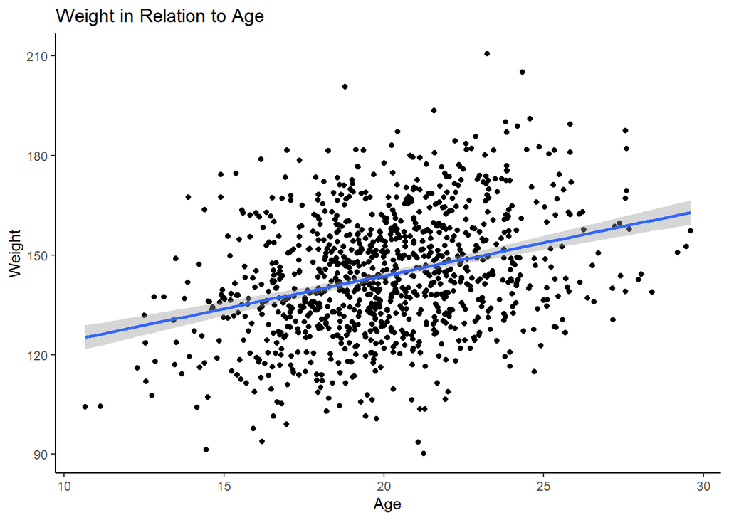

```r
ggplot(d, aes(x=a, y=w)) + geom_point() + geom_smooth(method=lm) + labs(title="Weight in Relation to Age", x="Age", y="Weight") + theme_classic() #Create scatterplot with weight in relationship to age.
```

According to the scatterplots, height is more related to age than weight is related to age. They both appear to be slightly related, as the regression lines follow a positive linear pattern for both, but the line is more steep for the height scatterplot. Therefore, I would say height is more related to age than weight.

## Question 4

Using histograms and Q-Q plots, check whether the quantitative variables seem to be drawn from a normal distribution. Which seem to be and which do not (hint: not all are drawn from the normal distribution)? For those that are not normal, can you determine from which common distribution they are drawn?

In this question I will continue to use the vectors created earlier.

### Height

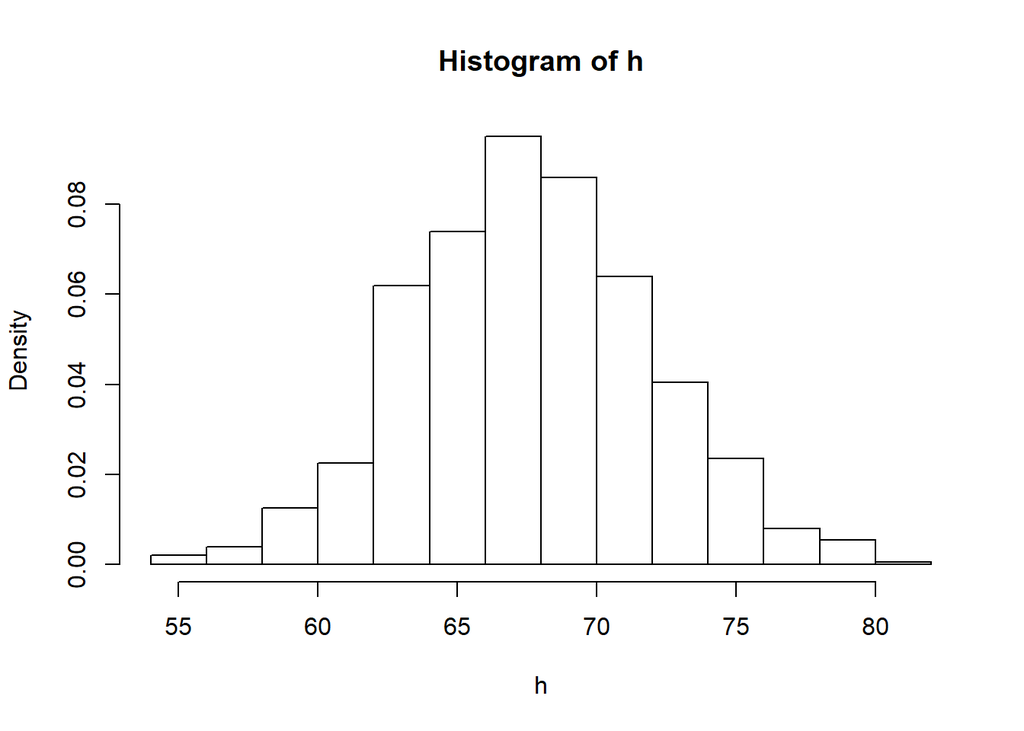

```r
hist(h, probability = TRUE) #Create histogram for height values
```

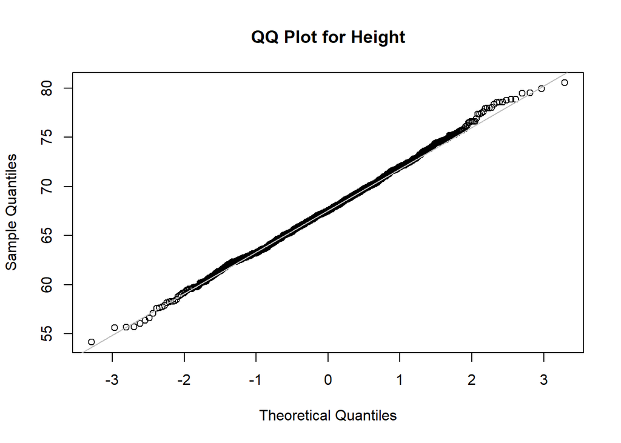

```r
qqnorm(h,main="QQ Plot for Height")
qqline(h,col="gray") #Create Q-Q plot for height values.
```

According to the two plots, height has a normal distribution.

### Weight

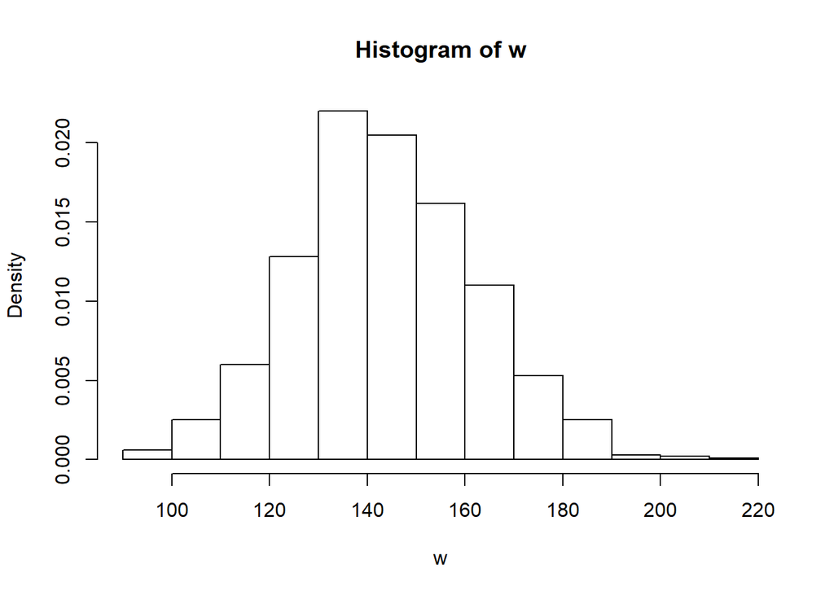

```r
hist(w, probability = TRUE) #Create histogram for weight values
```

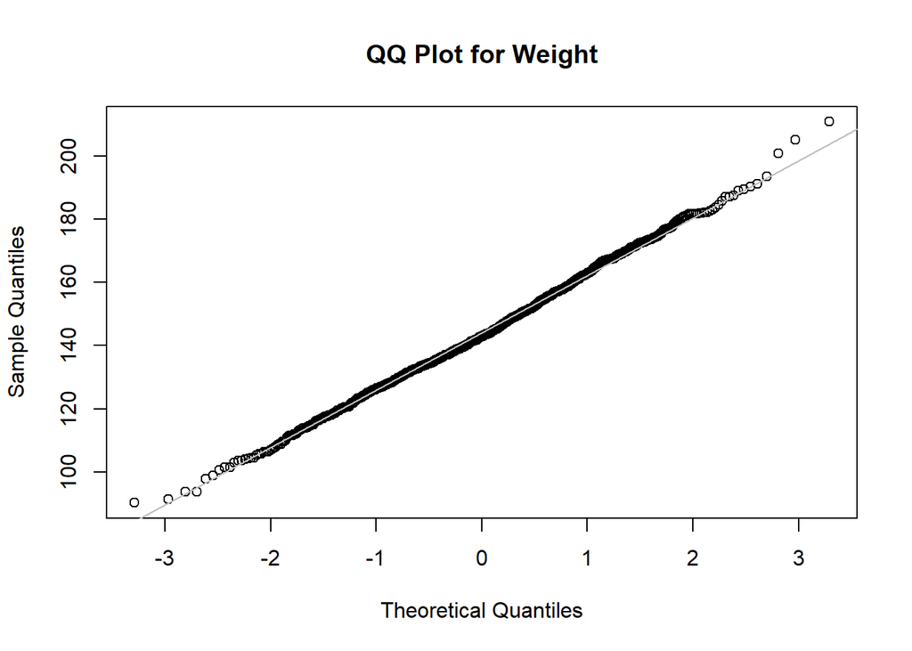

```r
qqnorm(w,main="QQ Plot for Weight")
qqline(w,col="gray") #Create Q-Q plot for weight values.
```

According to the two plots, weight has a normal distribution.

### Age

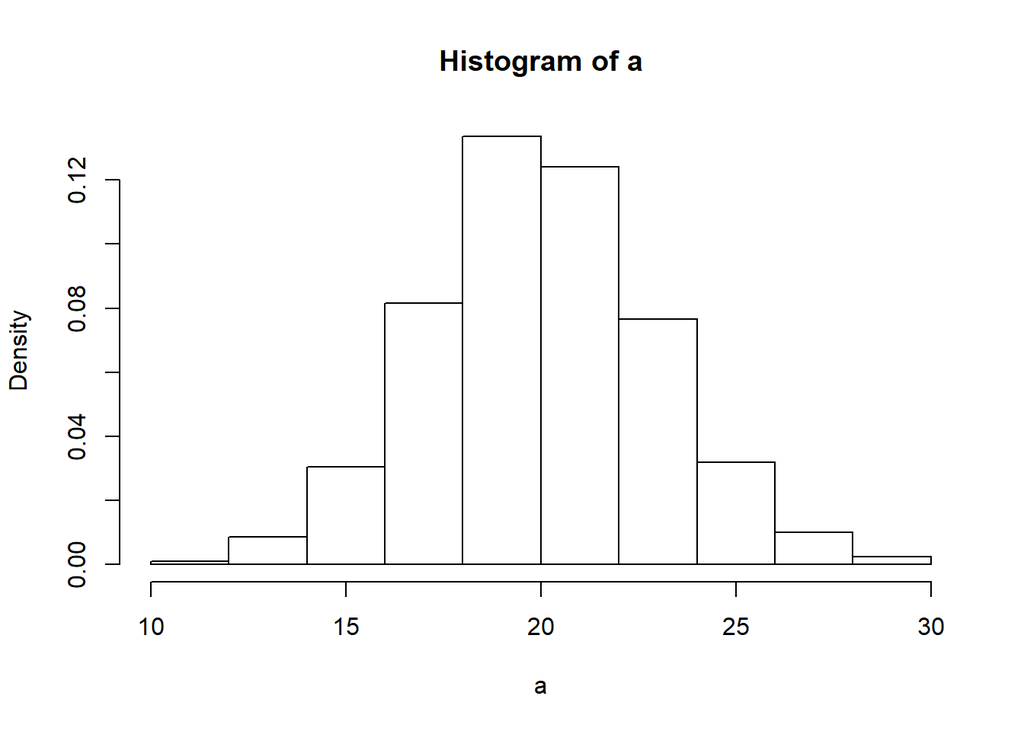

```r
hist(a, probability = TRUE) #Create histogram for age values
```

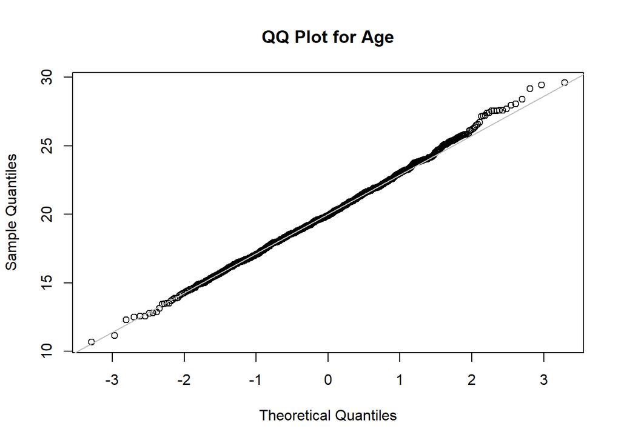

```r
qqnorm(a,main="QQ Plot for Age")
qqline(a,col="gray") #Create Q-Q plot for age values.
```

According to the two plots, age has a normal distrbution.

### Number of Zombies Killed

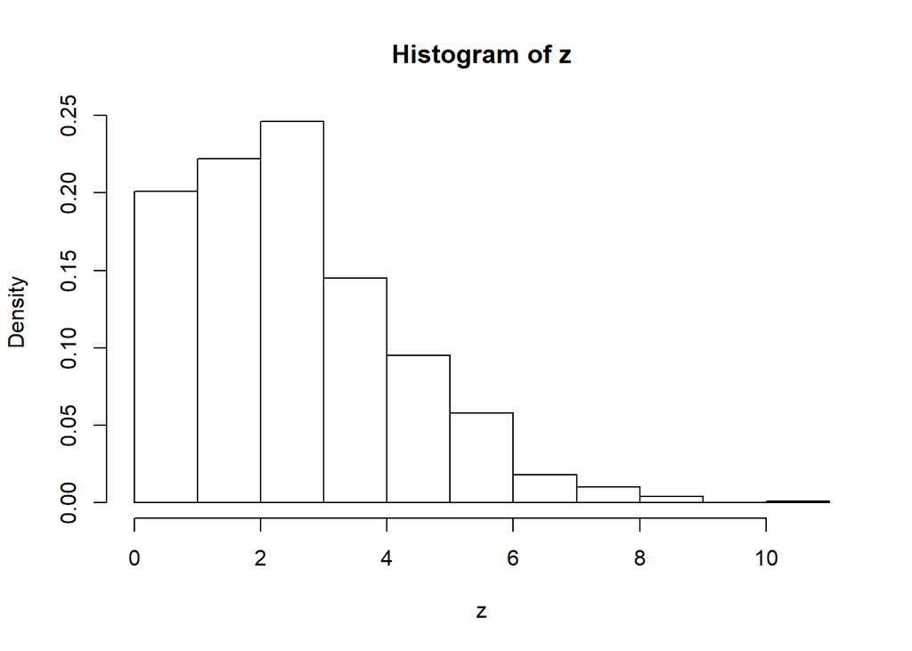

```r
hist(z, probability = TRUE) #Create histogram for number of zombies killed values
```

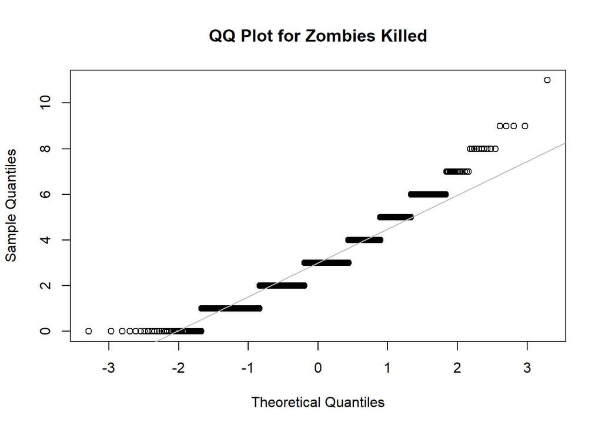

```r
qqnorm(z,main="QQ Plot for Zombies Killed")
qqline(z,col="gray") #Create Q-Q plot for number of zombies killed values.
```

According to the two plots, the number of zombies killed does not have a normal distribution. It appears to have a Poisson distribution, which I can test for below.

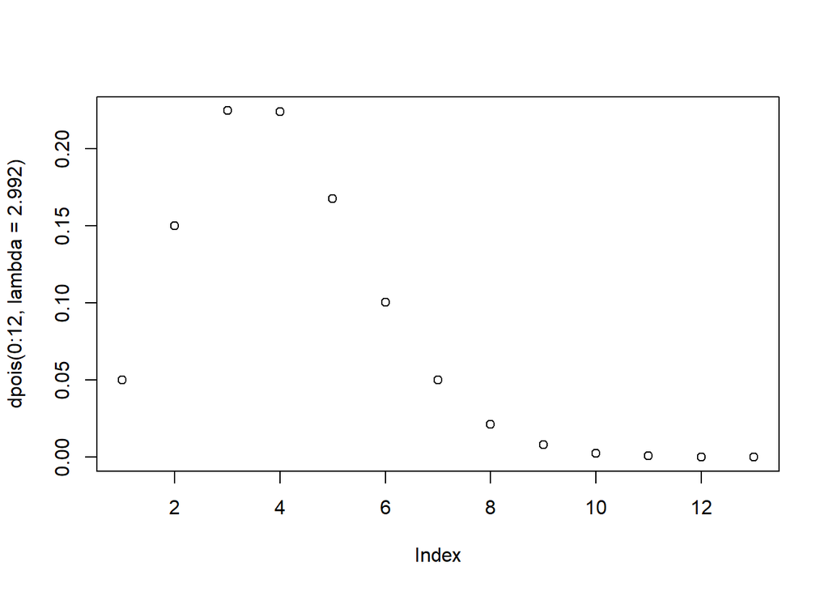

```r
plot(dpois(0:12, lambda = 2.992)) #Create plot showing Poisson distribution with range being 0 to 12, the max amount of zombies killed, and lambda being the mean.
```

This looks more normally distributed than before.

### Years of Education

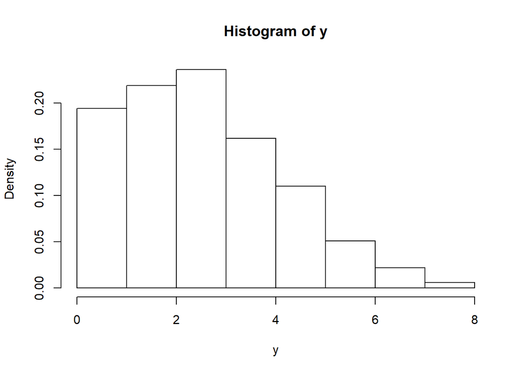

```r
hist(y, probability = TRUE) #Create histogram for years of education values
```

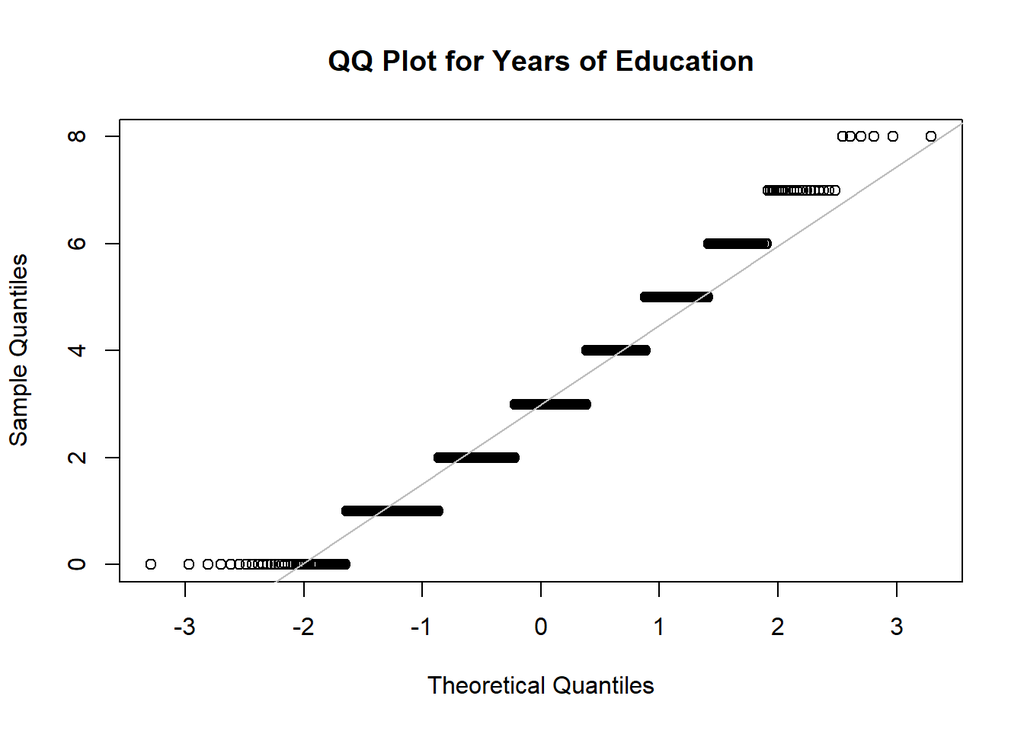

```r
qqnorm(y,main="QQ Plot for Years of Education")
qqline(y,col="gray") #Create Q-Q plot for years of education values.
```

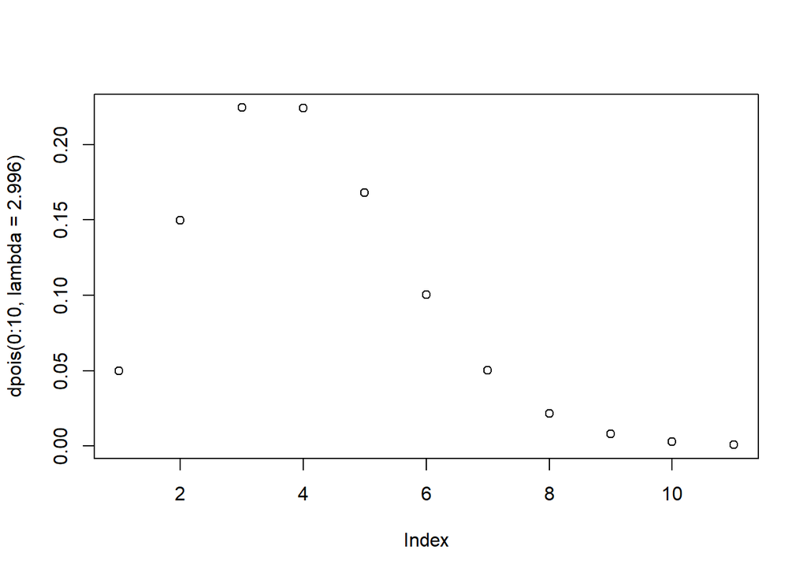

```r
plot(dpois(0:10, lambda = 2.996)) #Create plot for Poisson distribution with range being 0 to 10, 8 is the max, but I think 9 is a weird place to cut it off, as well as with lambda being the mean.
```

This also looks more normally distributed than before.

## Question 5

Now use the sample() function to sample ONE subset of 30 zombie survivors (without replacement) from this population and calculate the mean and sample standard deviation for each variable. Also estimate the standard error for each variable, and construct the 95% confidence interval for each mean. Note that for the variables that are not drawn from the normal distribution, you may need to base your estimate of the CIs on slightly different code than for the normal…

```r
s <- d[sample(nrow(d), 30), ] #Use vector with our dataset to create one sample of 30 people by picking whole rows instead of individual values.
s #Check our random sample
```

```
##      id  first_name  last_name gender   height   weight zombies_killed
## 636 636      Samuel Washington   Male 69.74712 143.6522              1
## 240 240        Lisa    Russell Female 67.29899 145.7219              5
## 665 665        Tina   Richards Female 66.06844 141.3945              0
## 968 968      Ernest     Hansen   Male 67.89409 159.2552              4
## 160 160     Mildred      Lopez Female 67.76443 134.7488              4
## 585 585    Patricia      Smith Female 64.63448 124.3808              3
## 831 831       Jason      Mason   Male 66.01576 140.0681              0
## 618 618       Janet    Johnson Female 62.32428 125.1633              2
## 372 372       Sarah     Foster Female 62.75796 109.6986              5
## 473 473     Matthew   Crawford   Male 78.36087 181.6597              2
## 574 574  Jacqueline       Cook Female 62.93356 125.8427              2
## 85   85     Anthony     Burton   Male 69.09528 162.6679              3
## 11   11     Matthew     Fuller   Male 70.66565 149.2834              4
## 280 280     Antonio    Vasquez   Male 70.79582 143.3083              2
```

[output cut: 47 more lines]

### Height

```r
#Create vector for height with small sample:
sh <- s$height
sh
```

```
##  [1] 69.74712 67.29899 66.06844 67.89409 67.76443 64.63448 66.01576
##  [8] 62.32428 62.75796 78.36087 62.93356 69.09528 70.66565 70.79582
## [15] 65.08026 65.80217 66.92469 62.29126 70.35090 74.16976 68.54200
## [22] 70.48223 68.13502 64.72491 74.69231 65.24568 63.35430 67.66987
## [29] 72.78263 69.07649
```

```r
#Finding sample mean:
shm <- mean(sh) #Use mean function to find the sample mean
shm
```

```
## [1] 67.85604
```

```r
#Finding sample standard deviation:
shsd <- sd(sh) #Use the standard deviation function to find the sample standard deviation.
shsd
```

```
## [1] 3.881012
```

```r
#Finding standard error:
hse <- shsd/sqrt(30) #Use standard deviation and devide by sample size to find the standard error
hse
```

```
## [1] 0.7085726
```

```r
#Finding CI:
lowerh <- shm - qnorm(1 - 0.05/shsd) * hse #Find the lower confidence interval for 95% with mean, standard deviation, and standard error
upperh <- shm + qnorm(1 - 0.05/shsd) * hse #Find the upper confidence interval for 95% with mean, standard deviation, and standard error
cih <- c(lowerh, upperh) #Put two values into confidence interval function
cih
```

```
## [1] 66.27613 69.43595
```

### Weight

```r
#Create vector for weight with small sample:
sw <- s$weight
sw
```

```
##  [1] 143.6522 145.7219 141.3945 159.2552 134.7488 124.3808 140.0681
##  [8] 125.1633 109.6986 181.6597 125.8427 162.6679 149.2834 143.3083
## [15] 155.5517 139.4154 138.4222 131.6759 158.2718 163.0445 144.7081
## [22] 169.9355 154.7702 126.4283 169.1259 150.6645 118.5460 152.8672
## [29] 149.9674 148.0729
```

```r
#Finding sample mean:
swm <- mean(sw) #Use mean function to find the sample mean
swm
```

```
## [1] 145.2771
```

```r
#Finding sample standard deviation:
swsd <- sd(sw) #Use the standard deviation function to find the sample standard deviation.
swsd
```

```
## [1] 16.39182
```

```r
#Finding standard error:
wse <- swsd/sqrt(30) #Use standard deviation and devide by sample size to find the standard error
wse
```

```
## [1] 2.992722
```

```r
#Finding CI:
lowerw <- swm - qnorm(1 - 0.05/swsd) * wse #Find the lower confidence interval for 95% with mean, standard deviation, and standard error
upperw <- swm + qnorm(1 - 0.05/swsd) * wse #Find the upper confidence interval for 95% with mean, standard deviation, and standard error
ciw <- c(lowerw, upperw) #Put two values into confidence interval function
ciw
```

```
## [1] 137.0701 153.4841
```

### Age

```r
#Create vector for age with small sample:
sa <- s$age
sa
```

```
##  [1] 20.39527 17.96663 19.81336 18.51140 22.49060 19.60460 17.95568
##  [8] 17.56003 20.29005 25.33842 18.56088 15.59753 24.15861 22.42920
## [15] 15.81956 18.84754 18.03707 17.63057 21.09164 23.24972 18.95085
## [22] 18.95161 15.47891 16.54507 23.55994 17.00379 21.93743 19.58388
## [29] 20.63110 18.94046
```

```r
#Finding sample mean:
sam <- mean(sa) #Use mean function to find the sample mean
sam
```

```
## [1] 19.56438
```

```r
#Finding sample standard deviation:
sasd <- sd(sa) #Use the standard deviation function to find the sample standard deviation.
sasd
```

```
## [1] 2.57488
```

```r
#Finding standard error:
ase <- sasd/sqrt(30) #Use standard deviation and devide by sample size to find the standard error
ase
```

```
## [1] 0.4701066
```

```r
#Finding CI:
lowera <- sam - qnorm(1 - 0.05/sasd) * ase #Find the lower confidence interval for 95% with mean, standard deviation, and standard error
uppera <- sam + qnorm(1 - 0.05/sasd) * ase #Find the upper confidence interval for 95% with mean, standard deviation, and standard error
cia <- c(lowera, uppera) #Put two values into confidence interval function
cia
```

```
## [1] 18.59318 20.53558
```

### Number of Zombies Killed

Note: The confidence interval code will have to be different due to a Poisson distribution!

```r
#Create vector for number of zombies killed with small sample:
sz <- s$zombies_killed
sz
```

```
##  [1] 1 5 0 4 4 3 0 2 5 2 2 3 4 2 2 2 4 1 4 3 4 2 5 4 0 5 2 2 2 2
```

```r
#Finding sample mean:
szm <- mean(sz) #Use mean function to find the sample mean
szm
```

```
## [1] 2.7
```

```r
#Finding sample standard deviation:
szsd <- sd(sz) #Use the standard deviation function to find the sample standard deviation.
szsd
```

```
## [1] 1.512021
```

```r
#Finding standard error:
zse <- szsd/sqrt(30) #Use standard deviation and devide by sample size to find the standard error
zse
```

```
## [1] 0.276056
```

```r
#Finding CI for Poisson distribution:
lowerz <- szm - qpois(0.05, szm) * zse #Find the lower confidence interval for 95% with mean, standard deviation, and standard error
upperz <- szm + qpois(0.95, szm) * zse #Find the upper confidence interval for 95% with mean, standard deviation, and standard error
ciz <- c(lowerz, upperz) #Put two values into confidence interval function
ciz
```

```
## [1] 2.700000 4.356336
```

### Years of Education

Note: The confidence interval code will have to be different due to a Poisson distribution!

```r
#Create vector for years of education with small sample:
sy <- s$years_of_education
sy
```

```
##  [1] 3 3 2 2 4 5 3 7 1 4 2 3 4 7 2 3 4 1 2 0 3 2 1 4 7 0 5 4 3 4
```

```r
#Finding sample mean:
sym <- mean(sy) #Use mean function to find the sample mean
sym
```

```
## [1] 3.166667
```

```r
#Finding sample standard deviation:
sysd <- sd(sy) #Use the standard deviation function to find the sample standard deviation.
sysd
```

```
## [1] 1.839853
```

```r
#Finding standard error:
yse <- sysd/sqrt(30) #Use standard deviation and devide by sample size to find the standard error
yse
```

```
## [1] 0.3359096
```

```r
#Finding CI for Poisson distribution:
lowery <- sym - qpois(0.05, sym) * yse #Find the lower confidence interval for 95% with mean, standard deviation, and standard error
uppery <- sym + qpois(0.95, sym) * yse #Find the upper confidence interval for 95% with mean, standard deviation, and standard error
ciy <- c(lowery, uppery) #Put two values into confidence interval function
ciy
```

```
## [1] 2.830757 5.182124
```

## Question 6

Now draw 99 more random samples of 30 zombie apocalypse survivors, and calculate the mean for each variable for each of these samples. Together with the first sample you drew, you now have a set of 100 means for each variable (each based on 30 observations), which constitutes a sampling distribution for each variable. What are the means and standard deviations of this distribution of means for each variable? How do the standard deviations of means compare to the standard errors estimated in [5]? What do these sampling distributions look like (a graph might help here)? Are they normally distributed? What about for those variables that you concluded were not originally drawn from a normal distribution?

### Height

```r
# Create a vector for the variable with 99 simulations:
nsh <- replicate(99,sample(d$height, 30, replace = FALSE))
nsh
```

```
##           [,1]     [,2]     [,3]     [,4]     [,5]     [,6]     [,7]
##  [1,] 68.02251 70.37832 73.29459 70.55803 75.23595 65.70558 64.72367
##  [2,] 70.34750 63.89230 60.36736 74.08120 63.35129 69.40155 68.58895
##  [3,] 65.21987 59.60174 75.73562 69.04027 71.51768 68.29221 63.73806
##  [4,] 68.74930 67.03964 74.47735 65.01620 74.51423 70.90769 67.54747
##  [5,] 68.40552 69.35963 65.49701 69.71188 66.30253 72.66829 71.14842
##  [6,] 62.70571 69.83051 70.28444 66.64840 66.06874 60.63871 75.21887
##  [7,] 67.18481 70.63257 69.05417 67.69123 66.58934 63.84095 70.10855
##  [8,] 68.03206 67.08054 75.23595 70.38518 66.21361 68.39093 72.25866
##  [9,] 62.33876 70.38518 70.09881 60.36736 61.04618 62.70571 70.46825
## [10,] 63.89230 59.29313 69.60290 65.18109 71.72562 60.67610 75.73562
## [11,] 65.24568 67.32648 72.33186 78.58725 69.07649 69.83051 73.13875
## [12,] 70.28444 64.01953 67.30731 77.89866 67.26091 70.25290 75.18322
## [13,] 73.06539 66.90534 65.34881 67.30597 59.82760 73.21277 67.89424
## [14,] 67.91683 70.66565 62.95986 72.15195 69.02792 65.63107 65.18479
```

[output cut: 450 more lines]

```r
#Find mean:
nshm <- mean(nsh)
nshm
```

```
## [1] 67.55583
```

```r
#Find standard deviation:
nshsd <- sd(nsh)
nshsd
```

```
## [1] 4.41581
```

The means are very close for both the one sample and the 99 samples, but the standard deviations are not as close.

### Weight

```r
# Create a vector for the variable with 99 simulations:
nsw <- replicate(99,sample(d$weight, 30, replace = FALSE))
nsw
```

```
##            [,1]     [,2]     [,3]     [,4]     [,5]     [,6]     [,7]
##  [1,] 150.89742 126.9184 174.3502 114.8988 153.7872 143.4554 165.9031
##  [2,] 132.18938 181.7031 155.7343 126.7012 141.3926 151.6608 109.6986
##  [3,] 150.55786 141.8587 145.4172 132.6426 164.9757 143.5878 168.9203
##  [4,] 171.24476 137.4624 145.2300 167.1739 145.4963 178.5852 181.8052
##  [5,] 144.88678 167.4862 146.8351 115.9745 157.0047 161.5712 134.3390
##  [6,] 154.90117 136.5139 119.9920 157.7349 148.7525 127.3202 115.0012
##  [7,] 148.07287 114.5466 180.5630 150.9086 131.5799 156.8429 155.5517
##  [8,] 135.90400 180.8674 138.8645 116.8043 142.6842 149.1646 150.9425
##  [9,] 165.00622 132.6426 134.4735 182.0792 166.9759 130.7100 157.6048
## [10,]  98.99585 146.1202 145.7389 131.5167 132.3134 137.0027 149.0745
## [11,] 142.84911 143.0793 157.4585 172.0195 140.0505 132.0872 133.5072
## [12,] 151.76066 140.2037 161.1856 157.7760 126.8076 145.5468 130.5163
## [13,] 149.53860 141.9159 157.6903 152.9015 111.5051 126.1780 165.4885
## [14,] 156.71838 159.3562 181.5567 141.5643 129.8401 129.8580 167.3627
```

[output cut: 450 more lines]

```r
#Find mean:
nswm <- mean(nsw)
nswm
```

```
## [1] 143.8103
```

```r
#Find standard deviation:
nswsd <- sd(nsw)
nswsd
```

```
## [1] 18.06386
```

The means for the one sample and the 99 samples are very close while the standard deviations are not as close.

### Age

```r
# Create a vector for the variable with 99 simulations:
nsa <- replicate(99,sample(d$age, 30, replace = FALSE))
nsa
```

```
##           [,1]     [,2]     [,3]     [,4]     [,5]     [,6]     [,7]
##  [1,] 22.95047 22.55533 20.35920 21.92487 21.33672 21.35953 21.98328
##  [2,] 25.09822 17.53114 21.61323 22.98415 24.73534 20.84978 21.27616
##  [3,] 22.55533 19.76865 17.79963 14.97051 22.15048 22.86259 19.18354
##  [4,] 25.36748 16.10785 17.34202 21.97145 17.58633 24.00616 19.50909
##  [5,] 17.07809 23.00981 25.42632 15.59753 18.55335 18.31888 24.30698
##  [6,] 13.76439 18.84435 21.48753 21.40550 16.70843 22.35990 17.77331
##  [7,] 21.93743 19.74585 25.29221 23.49016 22.95047 23.94809 18.51140
##  [8,] 25.10323 21.72252 17.96663 20.93726 21.66344 19.92577 21.09164
##  [9,] 22.39316 20.68250 20.37958 20.27556 14.39826 21.14685 21.11497
## [10,] 16.57199 20.57423 17.90379 16.51842 19.55108 18.75647 16.75516
## [11,] 19.18354 23.93911 18.23895 17.68825 20.67606 20.98622 18.61704
## [12,] 16.53939 24.01948 17.24751 21.29583 22.06032 19.08275 20.24794
## [13,] 16.62255 17.35896 17.95568 13.88697 18.73178 16.95885 24.37250
## [14,] 20.86853 22.02548 24.00647 18.54976 17.67847 19.43605 23.11572
```

[output cut: 450 more lines]

```r
#Find mean:
nsam <- mean(nsa)
nsam
```

```
## [1] 20.06754
```

```r
#Find standard deviation:
nsasd <- sd(nsa)
nsasd
```

```
## [1] 2.982356
```

The means for the one sample and the 99 samples are very close while the standard deviations are not as close.

### Number of Zombies Killed

```r
# Create a vector for the variable with 99 simulations:
nsz <- replicate(99,sample(d$zombies_killed, 30, replace = FALSE))
nsz
```

```
##       [,1] [,2] [,3] [,4] [,5] [,6] [,7] [,8] [,9] [,10] [,11] [,12] [,13]
##  [1,]    1    3    4    6    3    7    6    1    2     4     3     1     3
##  [2,]    2    2    2    4    3    6    1    2    0     2     3     5     5
##  [3,]    3    9    1    2    5    4    5    5    3     3     3     6     1
##  [4,]    3    0    1    3    3    3    6    0    3     1     5     2     0
##  [5,]    1    5    2    2    6    2    2    3    4     3     0     5     2
##  [6,]    4    3    2    3    3    3    3    4    5     2     5     3     2
##  [7,]    2    4    3    1    0    1    4    1    5     8     3     2     2
##  [8,]    4    3    3    0    3    0    5    3    2     2     5     4     1
##  [9,]    3    2    3    6    2    3    2    3    4     3     2     3     3
## [10,]    0    3    2    1    3    3    3    3    4     1     4     2     2
## [11,]    3    6    2    1    1    1    4    9    4     1     7     4     1
## [12,]    3    4    3    4    1    7    3    6    0     0     5     3     4
## [13,]    3    2    3    1    4    0    5    0    1     3     6     9     4
## [14,]    3    3    3    1    4    4    1    3    2     5     3     2     4
```

[output cut: 264 more lines]

```r
#Find mean:
nszm <- mean(nsz)
nszm
```

```
## [1] 2.980471
```

```r
#Find standard deviation:
nszsd <- sd(nsz)
nszsd
```

```
## [1] 1.733981
```

The means for the one sample and the 99 samples are very close and so are the standard deviation values.

### Years of Education

```r
# Create a vector for the variable with 99 simulations:
nsy <- replicate(99,sample(d$years_of_education, 30, replace = FALSE))
nsy
```

```
##       [,1] [,2] [,3] [,4] [,5] [,6] [,7] [,8] [,9] [,10] [,11] [,12] [,13]
##  [1,]    2    4    4    7    1    2    5    4    7     3     2     3     6
##  [2,]    7    3    2    5    0    4    4    2    5     3     1     5     2
##  [3,]    3    2    3    3    1    3    2    5    2     3     2     1     2
##  [4,]    0    2    4    6    2    2    7    1    2     1     2     5     1
##  [5,]    8    3    6    2    7    3    2    4    5     0     6     3     3
##  [6,]    4    2    5    4    2    3    4    3    3     2     3     4     2
##  [7,]    3    4    1    6    3    4    2    4    4     3     3     4     3
##  [8,]    3    3    4    2    7    4    4    1    2     4     3     5     1
##  [9,]    0    3    1    4    2    3    2    1    1     2     1     4     5
## [10,]    5    7    2    3    2    2    1    3    2     2     2     4     2
## [11,]    4    6    3    3    5    4    2    3    2     3     1     3     7
## [12,]    5    2    4    4    4    6    4    6    4     3     1     2     3
## [13,]    0    1    2    3    3    5    3    5    4     2     4     4     5
## [14,]    2    1    3    3    2    3    2    2    1     1     1     2     5
```

[output cut: 264 more lines]

```r
#Find mean:
nsym <- mean(nsy)
nsym
```

```
## [1] 3.008754
```

```r
#Find standard deviation:
nsysd <- sd(nsy)
nsysd
```

```
## [1] 1.674384
```

The means for the one sample and the 99 samples are very close and so are the standard deviation values.

### Testing for Normal Distribution

I now have to test to see if the 99 samples for each variable are normally distributed. I’m asusming all of them will be except for the two variables that were not previously: number of zombies killed and years of education. Let’s use a Q-Q plot for this.

### Height

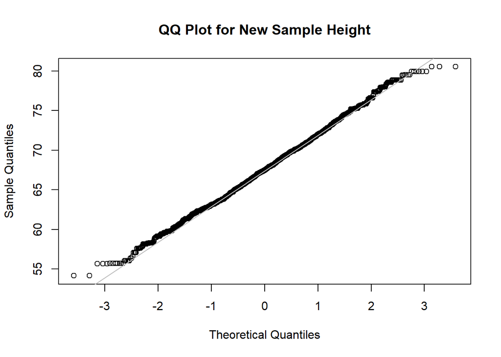

```r
qqnorm(nsh,main="QQ Plot for New Sample Height")
qqline(nsh,col="gray") #Create Q-Q plot for new sample height values.
```

The same as before, the height values are normally distributed.

### Weight

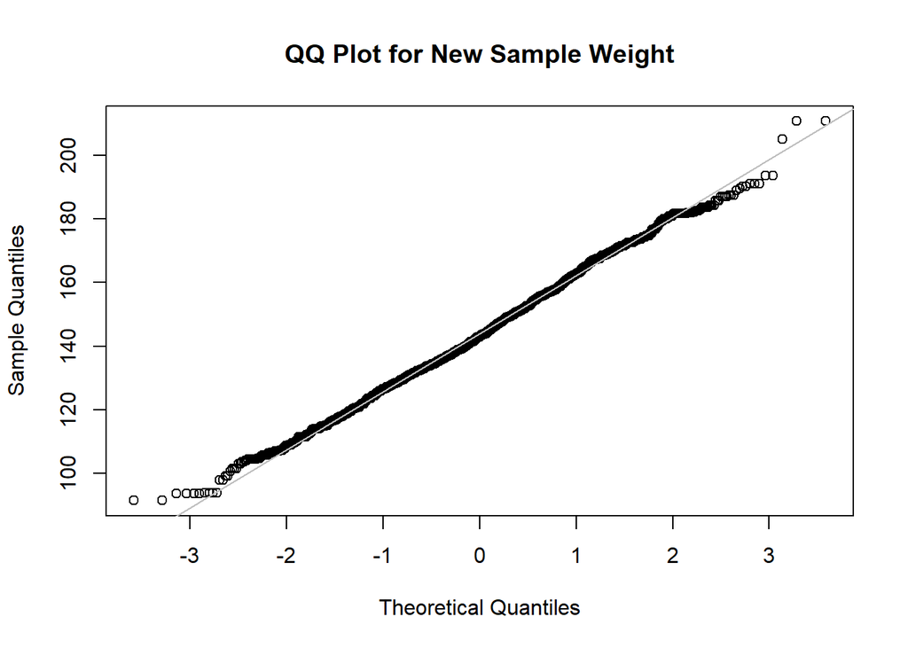

```r
qqnorm(nsw,main="QQ Plot for New Sample Weight")
qqline(nsw,col="gray") #Create Q-Q plot for new sample weight values.
```

The same as before, the weight values are normally distributed.

### Age

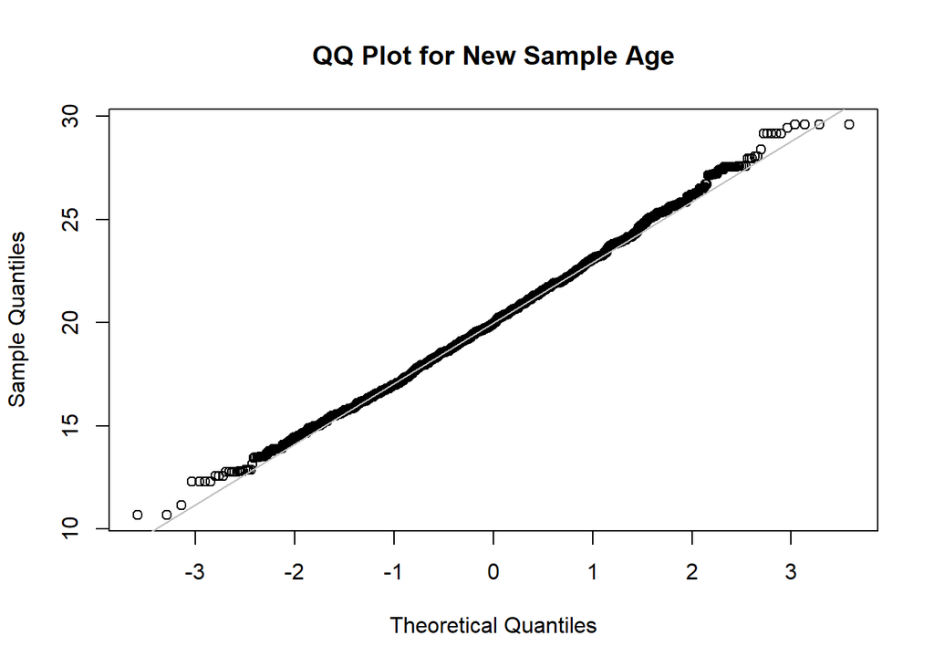

```r
qqnorm(nsa,main="QQ Plot for New Sample Age")
qqline(nsa,col="gray") #Create Q-Q plot for new sample age values.
```

The same as before, the age values are normally distributed.

### Number of Zombies Killed

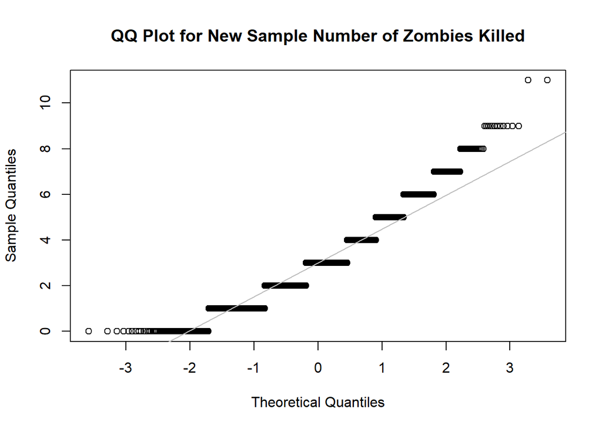

```r
qqnorm(nsz,main="QQ Plot for New Sample Number of Zombies Killed")
qqline(nsz,col="gray") #Create Q-Q plot for new sample number of zombies killed values.
```

The same as before, the number of zombies killed is not normally distributed with 99 random samples.

### Years of Education

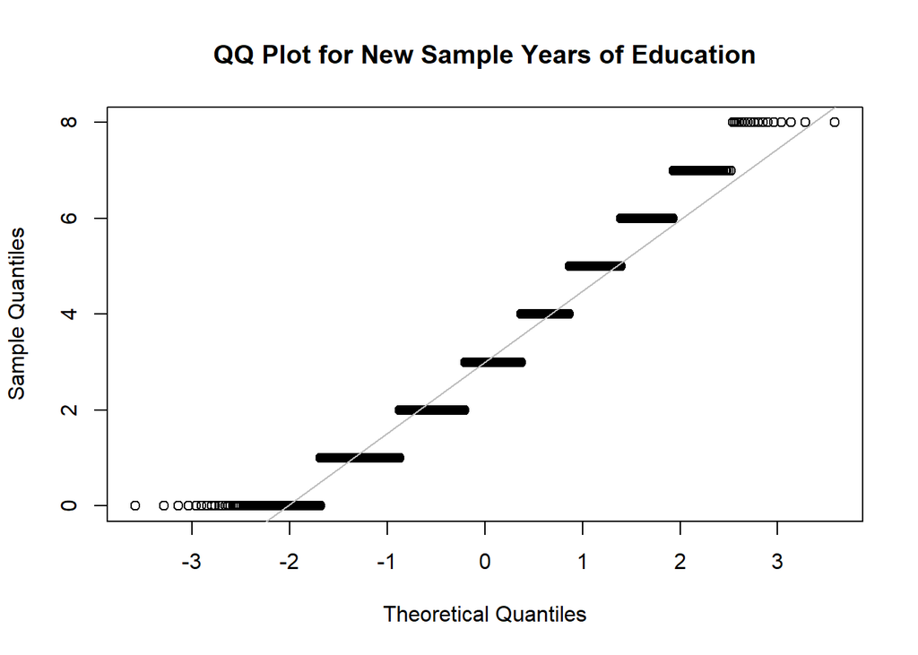

```r
qqnorm(nsy,main="QQ Plot for New Sample Years of Education")
qqline(nsy,col="gray") #Create Q-Q plot for new sample years of education values.
```

The same as before, the years of education is not normally distributed with 99 random samples.

## Challenges

1. Testing for what the distributions were for the number of zombies killed and the years of education.
2. Finding standard error for Question 5.
3. Creating confidence intervals for Question 5, both for the normal and Poisson distributions.
4. Creating 99 more random samples for Question 6. Did I do it right?
5. I’m kind of confused about what the questions is asking. Does he want me to find the means and standard deviations for the two vectors I’ve created, or just of the 99 more samples I found? I went with the 99 more samples found.